# Презентация по лабораторной работе №11

Текстовый редактор emacs

Барето Вилиан Мануел

Российский университет дружбы народов, Москва, Россия

24 Апреля 2025

# Информация

## Докладчик

- Барето Вилиан Мануел
- студент НКА 03-24
- факультет физико-математических и естественных наук
- Российский университет дружбы народов
- 1032239248@pfur.ru
- https://github.com/WMBarreto

# Цель работы

Получить практические навыки работы с редактором Emacs.

## Установка Emacs

Для данной работы, мне надо была установить Emacs:

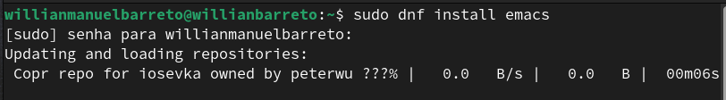

Установка Emacs

## Основные кманды с редактором

Выполнив Emacs в командной строке, я открыла текстовый редактор:

[figure not shown]

Emacs

## Основные кманды с редактором

С помощью комбинации Ctrl-x Ctrl-f, создала файл lab07.sh:

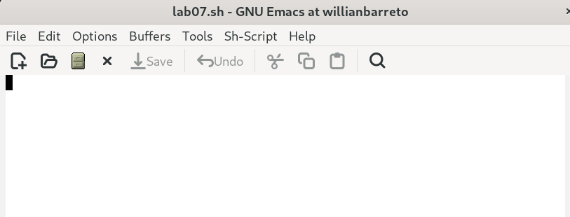

Созданный файл

## Основные кманды с редактором

Я сохранила файл с помощью комбинации Ctrl-x Ctrl-s:

[figure not shown]

текст в lab07.sh

## Основные кманды с редактором

Вырезать целую строку (С-k):

[figure not shown]

Вырезание строки

## Основные кманды с редактором

С помощью C-y вставила эту строку в конец файла:

[figure not shown]

Перемешение строку в конец файла

## Основные кманды с редактором

Выделила область текста (C-space):

[figure not shown]

Выделенный текст

## Основные кманды с редактором

Скопировала область в буфер обмена (M-w) и вставила ее в конец файла:

[figure not shown]

копирование и вставка

## Основные кманды с редактором

Выделила эту же область и на этот раз вырезала её (C-w):

[figure not shown]

ВЫрезанная область

## Основные кманды с редактором

С помощью C-/ отменила последнее действие:

[figure not shown]

отмена действие

## Основные кманды с редактором

С помощью C-a можно переместить курсор в начало строки. С помощью C-e переместила курсор в конец строки:

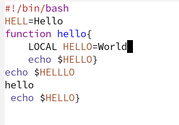

Перемещение курсор в конец строки

## Основные кманды с редактором

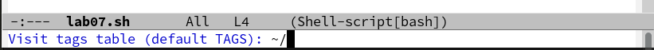

## Основные кманды с редактором

Выводила список активных буферов на экран с помощью C-x C-b:

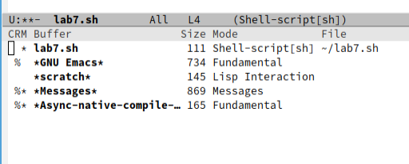

Активные буферы

## Основные кманды с редактором

С помощью C-x o переместилась во вновь открытое окно со списком открытых буферов и переключилась на другой буфер:

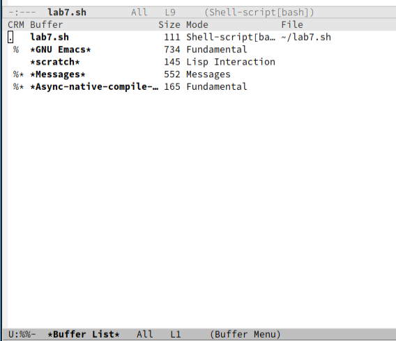

список открытых буферов

## Основные кманды с редактором

С помощью C-x 0 закрыла окно со списком открытых буферов:

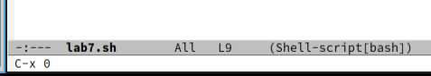

Закрытие окно

## Основные кманды с редактором

Без вывода списка буферов, я переключилась между буферами:

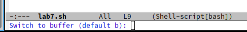

Переключение между буферами

## Основные кманды с редактором

[figure not shown]

Новый буфер

## Основные кманды с редактором

Поделила фрейм на 4 части. Сначала я разделила фрейм на два окна по вертикали (C-x 3), а затем каждое из этих окон на две части по горизонтали (C-x 2):

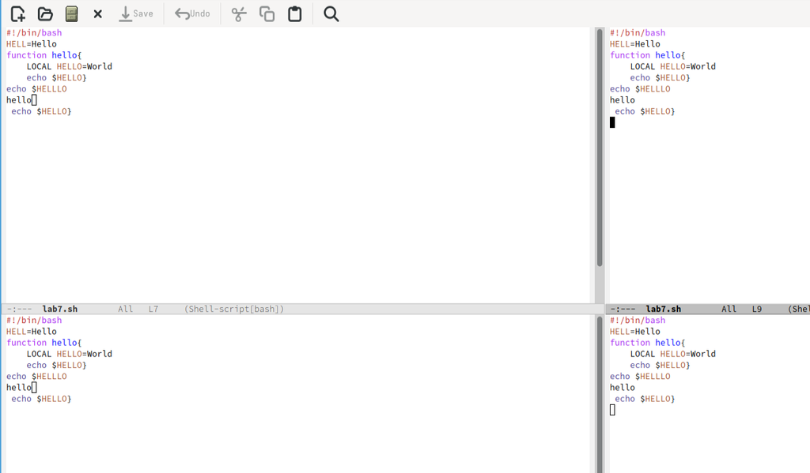

Фрейм разделённый на 4 окна

## Основные кманды с редактором

В каждом из четырёх созданных окон открыла новый буфер:

[figure not shown]

Новые буферы

## Основные кманды с редактором

Переключилась в режим поиска (C-s) и искала Indent:

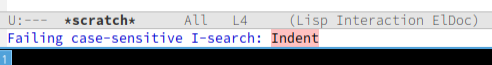

Режим поиска

## Основные кманды с редактором

Переключалась между результатами поиска, нажимая C-s и вышла из режима поиска, нажав C-g:

## Основные кманды с редактором

Перешла в режим поиска и замены (M-% или M-x query replace):

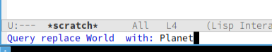

Режим поиска

## Основные кманды с редактором

Нажав M-s o, я использовала другой режим поиска. Он отличается от предыдущего тем, что выводит результаты поиска в новом окне:

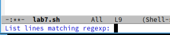

другой режим поиска

## Основные кманды с редактором

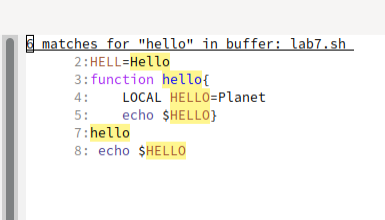

Результаты поиска

# Выводы

При выполнение данной работы я получила практические навыки работы с Emacs.